# code

Hi Everybody 👋🏻

#### Bank Loan Offer

| Column | Description |
| --- | --- |
| `ID` | Customer ID |
| `Age` | Customer's age |
| `Experience` | Years of customer experience |
| `Income` | Customer's annual income |
| `ZIP Code` | Customer's home address zipcode |
| `Family` | Customer's family members count |
| `CCAvg` | Avg. spending on credit cards per month |
| `Education` | Education level undergraduate: 1 graduated: 2 Advanced education: 3 |
| `Mortgage` | Value of house mortgage |
| `Personal Loan (target variable)` | Did the customers accept the offer in the last campaign? |
| `Securities Account` | Does the customer have a securities account with the bank? |
| `CD Account` | Does the customer have a certificate of deposit (CD) account with the bank? |
| `Online` | Does the customer use internet banking facilities? |
| `CreditCard` | Does the customer use a credit card issued by UniversalBank? |

#### About project:

Nowadays, the identification of customers and how to approach them is of utmost importance. Companies strive to determine the likelihood of customers accepting an offer before making it, enabling them to provide the most suitable offer to their customers.

In this dataset, we have numerous bank customers, each with their own set of characteristics. Ultimately, we aim to determine whether these customers have accepted previous loan offers from the bank or not. By developing an accurate model, we can predict whether another individual, to whom we are considering making a proposal, will accept or decline our offer.

# Table Of Content

## Table of Contents

- **Step 1 | Nessesary Libraries**
  - 1.1 | Import Libraries
  - 1.2 | Library configurations
- **Step 2 | Dataset**
  - 2.1 | Load dataset
  - 2.2 | About dataset
- **Step 3 | Preprocessing**
  - 3.1 | Check "CCAvg"
  - 3.2 | Check "Experience"
  - 3.3 | Missing values
  - 3.4 | Duplicated values
  - 3.5 | Noise
  - 3.6 | Plots
- **Step 4 | Modeling**
  - 4.1 | Features selection
  - 4.2 | Logestic Regression
  - 4.3 | KNN
  - 4.4 | Complement Naive Bayes (CNB)
  - 4.5 | Decision Tree classifier
  - 4.6 | Random Forest classifier
  - 4.7 | Result
- **Author**

# Step 1 | Nessasary Libraries

##### 📍If you don't have libraries, then you should install them. (ex. pip install pandas)

## **Step 1.1 | Import Libraries**

```python
import pandas as pd
import numpy as np
import matplotlib.pyplot as plt
import plotly.express as px
import seaborn as sns
import zipcodes as zcode
import folium

from sklearn.model_selection import train_test_split
from sklearn.linear_model import LogisticRegression
from sklearn.neighbors import KNeighborsClassifier
from sklearn.naive_bayes import ComplementNB
from sklearn.model_selection import GridSearchCV
from sklearn.tree import DecisionTreeClassifier
from sklearn.ensemble import RandomForestClassifier
from sklearn import metrics
from sklearn.metrics import classification_report, confusion_matrix
```

## **Step 1.1 | Library configurations**

```python
plt.style.use('bmh')
```

```python
import warnings
warnings.filterwarnings("ignore")
```

```python
from plotly.offline import init_notebook_mode, iplot
init_notebook_mode(connected=True)
```

# Step 2 | Dataset

## **Step 2.1 | Load dataset**

##### 📍Here, we import data from a csv file, using pandas library.

```python
data = pd.read_csv ("Bank_Personal_Loan.csv")
df = pd.DataFrame(data)
df
```

|  | ID | Age | Experience | Income | ZIP Code | Family | CCAvg | Education | Mortgage | Personal Loan | Securities Account | CD Account | Online | CreditCard |
| --- | --- | --- | --- | --- | --- | --- | --- | --- | --- | --- | --- | --- | --- | --- |
| 0 | 1 | 25 | 1 | 49 | 91107 | 4 | 1/60 | 1 | 0 | 0 | 1 | 0 | 0 | 0 |
| 1 | 2 | 45 | 19 | 34 | 90089 | 3 | 1/50 | 1 | 0 | 0 | 1 | 0 | 0 | 0 |
| 2 | 3 | 39 | 15 | 11 | 94720 | 1 | 1/00 | 1 | 0 | 0 | 0 | 0 | 0 | 0 |
| 3 | 4 | 35 | 9 | 100 | 94112 | 1 | 2/70 | 2 | 0 | 0 | 0 | 0 | 0 | 0 |
| 4 | 5 | 35 | 8 | 45 | 91330 | 4 | 1/00 | 2 | 0 | 0 | 0 | 0 | 0 | 1 |
| ... | ... | ... | ... | ... | ... | ... | ... | ... | ... | ... | ... | ... | ... | ... |
| 4995 | 4996 | 29 | 3 | 40 | 92697 | 1 | 1/90 | 3 | 0 | 0 | 0 | 0 | 1 | 0 |
| 4996 | 4997 | 30 | 4 | 15 | 92037 | 4 | 0/40 | 1 | 85 | 0 | 0 | 0 | 1 | 0 |
| 4997 | 4998 | 63 | 39 | 24 | 93023 | 2 | 0/30 | 3 | 0 | 0 | 0 | 0 | 0 | 0 |
| 4998 | 4999 | 65 | 40 | 49 | 90034 | 3 | 0/50 | 2 | 0 | 0 | 0 | 0 | 1 | 0 |
| 4999 | 5000 | 28 | 4 | 83 | 92612 | 3 | 0/80 | 1 | 0 | 0 | 0 | 0 | 1 | 1 |

5000 rows × 14 columns

##### 📍All the column names in the DataFrame will have any spaces replaced with underscores.

```python
df.columns = [c.replace(' ', '_') for c in df.columns]
df
```

|  | ID | Age | Experience | Income | ZIP_Code | Family | CCAvg | Education | Mortgage | Personal_Loan | Securities_Account | CD_Account | Online | CreditCard |
| --- | --- | --- | --- | --- | --- | --- | --- | --- | --- | --- | --- | --- | --- | --- |
| 0 | 1 | 25 | 1 | 49 | 91107 | 4 | 1/60 | 1 | 0 | 0 | 1 | 0 | 0 | 0 |
| 1 | 2 | 45 | 19 | 34 | 90089 | 3 | 1/50 | 1 | 0 | 0 | 1 | 0 | 0 | 0 |
| 2 | 3 | 39 | 15 | 11 | 94720 | 1 | 1/00 | 1 | 0 | 0 | 0 | 0 | 0 | 0 |
| 3 | 4 | 35 | 9 | 100 | 94112 | 1 | 2/70 | 2 | 0 | 0 | 0 | 0 | 0 | 0 |
| 4 | 5 | 35 | 8 | 45 | 91330 | 4 | 1/00 | 2 | 0 | 0 | 0 | 0 | 0 | 1 |
| ... | ... | ... | ... | ... | ... | ... | ... | ... | ... | ... | ... | ... | ... | ... |
| 4995 | 4996 | 29 | 3 | 40 | 92697 | 1 | 1/90 | 3 | 0 | 0 | 0 | 0 | 1 | 0 |
| 4996 | 4997 | 30 | 4 | 15 | 92037 | 4 | 0/40 | 1 | 85 | 0 | 0 | 0 | 1 | 0 |
| 4997 | 4998 | 63 | 39 | 24 | 93023 | 2 | 0/30 | 3 | 0 | 0 | 0 | 0 | 0 | 0 |
| 4998 | 4999 | 65 | 40 | 49 | 90034 | 3 | 0/50 | 2 | 0 | 0 | 0 | 0 | 1 | 0 |
| 4999 | 5000 | 28 | 4 | 83 | 92612 | 3 | 0/80 | 1 | 0 | 0 | 0 | 0 | 1 | 1 |

5000 rows × 14 columns

## **Step 2.2 | About dataset**

##### 📍`.shape` returns the row and column count of the DataFrame in a simple tuple format. 📍`.head` returns a subset of rows from the top of the DataFrame, allowing convenient previewing of the start of the data. 📍`.info`provides a succinct summary of a DataFrame. It gives concise information about column names, data types, non-missing values and memory usage. 📍`.describe(include='all')` provides a high-level summary of numeric and object columns in a DataFrame.

```python
row, col = df.shape
print("This Dataset have",row,"rows and",col,"columns.")
```

```
This Dataset have 5000 rows and 14 columns.
```

```python
df.head()
```

|  | ID | Age | Experience | Income | ZIP_Code | Family | CCAvg | Education | Mortgage | Personal_Loan | Securities_Account | CD_Account | Online | CreditCard |
| --- | --- | --- | --- | --- | --- | --- | --- | --- | --- | --- | --- | --- | --- | --- |
| 0 | 1 | 25 | 1 | 49 | 91107 | 4 | 1/60 | 1 | 0 | 0 | 1 | 0 | 0 | 0 |
| 1 | 2 | 45 | 19 | 34 | 90089 | 3 | 1/50 | 1 | 0 | 0 | 1 | 0 | 0 | 0 |
| 2 | 3 | 39 | 15 | 11 | 94720 | 1 | 1/00 | 1 | 0 | 0 | 0 | 0 | 0 | 0 |
| 3 | 4 | 35 | 9 | 100 | 94112 | 1 | 2/70 | 2 | 0 | 0 | 0 | 0 | 0 | 0 |
| 4 | 5 | 35 | 8 | 45 | 91330 | 4 | 1/00 | 2 | 0 | 0 | 0 | 0 | 0 | 1 |

```python
df.info()
```

```
<class 'pandas.core.frame.DataFrame'>
RangeIndex: 5000 entries, 0 to 4999
Data columns (total 14 columns):
 #   Column              Non-Null Count  Dtype
---  ------              --------------  -----
 0   ID                  5000 non-null   int64
 1   Age                 5000 non-null   int64
 2   Experience          5000 non-null   int64
 3   Income              5000 non-null   int64
 4   ZIP_Code            5000 non-null   int64
 5   Family              5000 non-null   int64
 6   CCAvg               5000 non-null   object
 7   Education           5000 non-null   int64
 8   Mortgage            5000 non-null   int64
 9   Personal_Loan       5000 non-null   int64
 10  Securities_Account  5000 non-null   int64
 11  CD_Account          5000 non-null   int64
 12  Online              5000 non-null   int64
 13  CreditCard          5000 non-null   int64
dtypes: int64(13), object(1)
memory usage: 547.0+ KB
```

##### ⚠️ Pay attention to the value and dtype of the "CCAvg" column.

```python
df.describe(include='all')
```

|  | ID | Age | Experience | Income | ZIP_Code | Family | CCAvg | Education | Mortgage | Personal_Loan | Securities_Account | CD_Account | Online | CreditCard |
| --- | --- | --- | --- | --- | --- | --- | --- | --- | --- | --- | --- | --- | --- | --- |
| count | 5000.000000 | 5000.000000 | 5000.000000 | 5000.000000 | 5000.000000 | 5000.000000 | 5000 | 5000.000000 | 5000.000000 | 5000.000000 | 5000.000000 | 5000.00000 | 5000.000000 | 5000.000000 |
| unique | NaN | NaN | NaN | NaN | NaN | NaN | 108 | NaN | NaN | NaN | NaN | NaN | NaN | NaN |
| top | NaN | NaN | NaN | NaN | NaN | NaN | 0/30 | NaN | NaN | NaN | NaN | NaN | NaN | NaN |
| freq | NaN | NaN | NaN | NaN | NaN | NaN | 241 | NaN | NaN | NaN | NaN | NaN | NaN | NaN |
| mean | 2500.500000 | 45.338400 | 20.104600 | 73.774200 | 93152.503000 | 2.396400 | NaN | 1.881000 | 56.498800 | 0.096000 | 0.104400 | 0.06040 | 0.596800 | 0.294000 |
| std | 1443.520003 | 11.463166 | 11.467954 | 46.033729 | 2121.852197 | 1.147663 | NaN | 0.839869 | 101.713802 | 0.294621 | 0.305809 | 0.23825 | 0.490589 | 0.455637 |
| min | 1.000000 | 23.000000 | -3.000000 | 8.000000 | 9307.000000 | 1.000000 | NaN | 1.000000 | 0.000000 | 0.000000 | 0.000000 | 0.00000 | 0.000000 | 0.000000 |
| 25% | 1250.750000 | 35.000000 | 10.000000 | 39.000000 | 91911.000000 | 1.000000 | NaN | 1.000000 | 0.000000 | 0.000000 | 0.000000 | 0.00000 | 0.000000 | 0.000000 |
| 50% | 2500.500000 | 45.000000 | 20.000000 | 64.000000 | 93437.000000 | 2.000000 | NaN | 2.000000 | 0.000000 | 0.000000 | 0.000000 | 0.00000 | 1.000000 | 0.000000 |
| 75% | 3750.250000 | 55.000000 | 30.000000 | 98.000000 | 94608.000000 | 3.000000 | NaN | 3.000000 | 101.000000 | 0.000000 | 0.000000 | 0.00000 | 1.000000 | 1.000000 |
| max | 5000.000000 | 67.000000 | 43.000000 | 224.000000 | 96651.000000 | 4.000000 | NaN | 3.000000 | 635.000000 | 1.000000 | 1.000000 | 1.00000 | 1.000000 | 1.000000 |

##### ⚠️ min value of column "Experience" isn't reasonable.

# Step 3 | Preprocessing

##### 📍 Drop "ID" column.

```python
df.drop(["ID"], axis=1, inplace=True)
```

## **Step 3.1 | Check "CCAvg"**

##### 📍 In order to be able to change the data type of the "CCAvg" column to float, we must correct the value of the column. ( Change "/" to "." )

```python
df['CCAvg'] = df['CCAvg'].str.replace('/', '.')
df
```

|  | Age | Experience | Income | ZIP_Code | Family | CCAvg | Education | Mortgage | Personal_Loan | Securities_Account | CD_Account | Online | CreditCard |
| --- | --- | --- | --- | --- | --- | --- | --- | --- | --- | --- | --- | --- | --- |
| 0 | 25 | 1 | 49 | 91107 | 4 | 1.60 | 1 | 0 | 0 | 1 | 0 | 0 | 0 |
| 1 | 45 | 19 | 34 | 90089 | 3 | 1.50 | 1 | 0 | 0 | 1 | 0 | 0 | 0 |
| 2 | 39 | 15 | 11 | 94720 | 1 | 1.00 | 1 | 0 | 0 | 0 | 0 | 0 | 0 |
| 3 | 35 | 9 | 100 | 94112 | 1 | 2.70 | 2 | 0 | 0 | 0 | 0 | 0 | 0 |
| 4 | 35 | 8 | 45 | 91330 | 4 | 1.00 | 2 | 0 | 0 | 0 | 0 | 0 | 1 |
| ... | ... | ... | ... | ... | ... | ... | ... | ... | ... | ... | ... | ... | ... |
| 4995 | 29 | 3 | 40 | 92697 | 1 | 1.90 | 3 | 0 | 0 | 0 | 0 | 1 | 0 |
| 4996 | 30 | 4 | 15 | 92037 | 4 | 0.40 | 1 | 85 | 0 | 0 | 0 | 1 | 0 |
| 4997 | 63 | 39 | 24 | 93023 | 2 | 0.30 | 3 | 0 | 0 | 0 | 0 | 0 | 0 |
| 4998 | 65 | 40 | 49 | 90034 | 3 | 0.50 | 2 | 0 | 0 | 0 | 0 | 1 | 0 |
| 4999 | 28 | 4 | 83 | 92612 | 3 | 0.80 | 1 | 0 | 0 | 0 | 0 | 1 | 1 |

5000 rows × 13 columns

```python
df['CCAvg'] = df['CCAvg'].astype('float')
df['CCAvg'].dtype
```

```
dtype('float64')
```

##### 📍 Let's convert the unit of measurement for "CCAvg" from per month to per year.

```python
df['CCAvg'] = df['CCAvg']*12
```

```python
df["CCAvg"].describe()
```

```
count    5000.000000
mean       23.255256
std        20.971908
min         0.000000
25%         8.400000
50%        18.000000
75%        30.000000
max       120.000000
Name: CCAvg, dtype: float64
```

## **Step 3.2 | Check "Experience"**

##### 📍 Use `abs()` to returns the absolute values of "Experience" column.

```python
df['Experience'] = abs(df['Experience'])
```

```python
df['Experience'].describe()
```

```
count    5000.000000
mean       20.134600
std        11.415189
min         0.000000
25%        10.000000
50%        20.000000
75%        30.000000
max        43.000000
Name: Experience, dtype: float64
```

## **Step 3.3 | Missing values**

```python
df.isnull().sum()
```

```
Age                   0
Experience            0
Income                0
ZIP_Code              0
Family                0
CCAvg                 0
Education             0
Mortgage              0
Personal_Loan         0
Securities_Account    0
CD_Account            0
Online                0
CreditCard            0
dtype: int64
```

##### ✅ There is no Missing values in Dataframe.

## **Step 3.4 | Duplicated values**

```python
df_duplicated = df.copy()
df_duplicated.drop_duplicates(subset=None, inplace=True)

df_duplicated.shape
```

```
(5000, 13)
```

```python
df.shape
```

```
(5000, 13)
```

##### ✅ There is no duplicated values in Dataframe.

```python
df.describe()
```

|  | Age | Experience | Income | ZIP_Code | Family | CCAvg | Education | Mortgage | Personal_Loan | Securities_Account | CD_Account | Online | CreditCard |
| --- | --- | --- | --- | --- | --- | --- | --- | --- | --- | --- | --- | --- | --- |
| count | 5000.000000 | 5000.000000 | 5000.000000 | 5000.000000 | 5000.000000 | 5000.000000 | 5000.000000 | 5000.000000 | 5000.000000 | 5000.000000 | 5000.00000 | 5000.000000 | 5000.000000 |
| mean | 45.338400 | 20.134600 | 73.774200 | 93152.503000 | 2.396400 | 23.255256 | 1.881000 | 56.498800 | 0.096000 | 0.104400 | 0.06040 | 0.596800 | 0.294000 |
| std | 11.463166 | 11.415189 | 46.033729 | 2121.852197 | 1.147663 | 20.971908 | 0.839869 | 101.713802 | 0.294621 | 0.305809 | 0.23825 | 0.490589 | 0.455637 |
| min | 23.000000 | 0.000000 | 8.000000 | 9307.000000 | 1.000000 | 0.000000 | 1.000000 | 0.000000 | 0.000000 | 0.000000 | 0.00000 | 0.000000 | 0.000000 |
| 25% | 35.000000 | 10.000000 | 39.000000 | 91911.000000 | 1.000000 | 8.400000 | 1.000000 | 0.000000 | 0.000000 | 0.000000 | 0.00000 | 0.000000 | 0.000000 |
| 50% | 45.000000 | 20.000000 | 64.000000 | 93437.000000 | 2.000000 | 18.000000 | 2.000000 | 0.000000 | 0.000000 | 0.000000 | 0.00000 | 1.000000 | 0.000000 |
| 75% | 55.000000 | 30.000000 | 98.000000 | 94608.000000 | 3.000000 | 30.000000 | 3.000000 | 101.000000 | 0.000000 | 0.000000 | 0.00000 | 1.000000 | 1.000000 |
| max | 67.000000 | 43.000000 | 224.000000 | 96651.000000 | 4.000000 | 120.000000 | 3.000000 | 635.000000 | 1.000000 | 1.000000 | 1.00000 | 1.000000 | 1.000000 |

## **Step 3.5 | Noise**

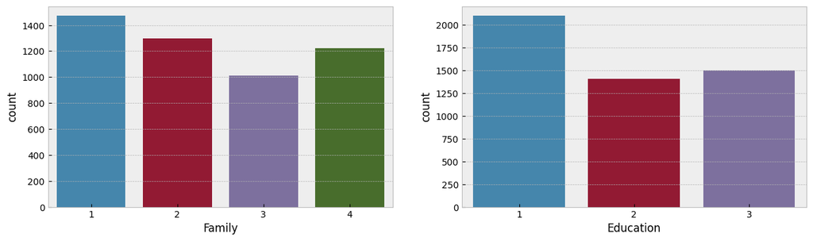

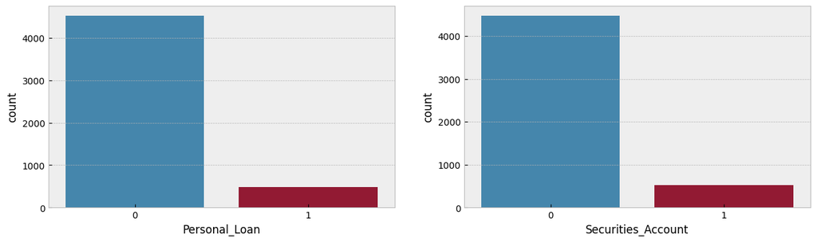

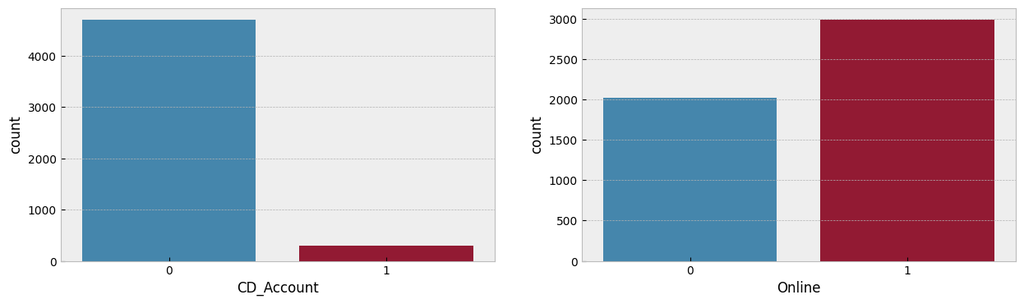

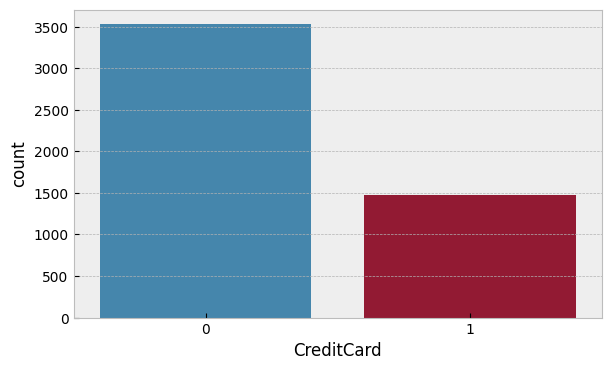

```python
Categorical = ['Family', 'Education', 'Personal_Loan', 'Securities_Account',
               'CD_Account', 'Online', 'CreditCard']
i = 0
while i <= 7 :
    fig = plt.figure(figsize=[15,4])
    plt.subplot(1,2,1)
    sns.countplot(x=Categorical[i], data=df)
    i += 1
    if i == 7 :
        break
    plt.subplot(1,2,2)
    sns.countplot(x=Categorical[i], data=df)
    i += 1
    plt.show()
```

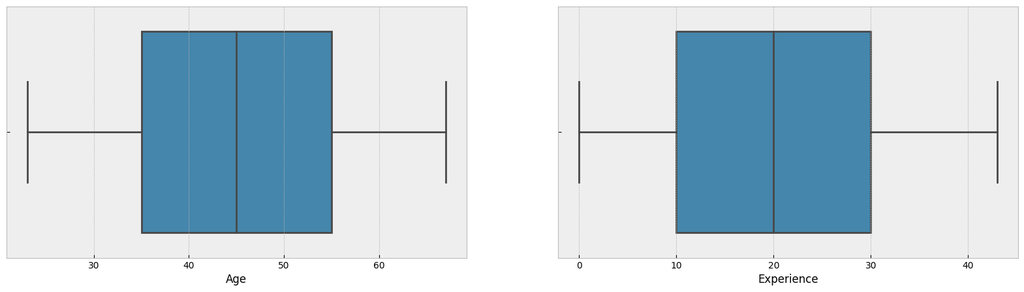

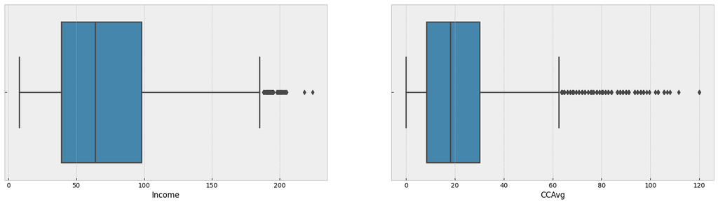

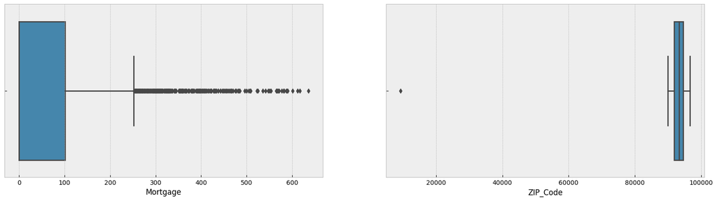

```python
Numerical = [ 'Age', 'Experience', 'Income',  'CCAvg', 'Mortgage', 'ZIP_Code']
i = 0
while i < 6 :
    fig = plt.figure(figsize=[20,5])
    plt.subplot(1,2,1)
    sns.boxplot(x= Numerical[i], data=df)
    i += 1
    if i == 6:
        break
    plt.subplot(1,2,2)
    sns.boxplot(x= Numerical[i], data=df)
    i += 1
    plt.show()
```

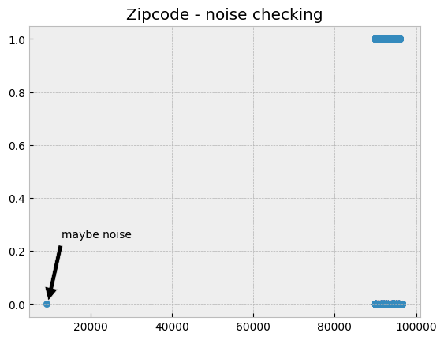

```python
plt.scatter(df['ZIP_Code'], df["Personal_Loan"])
plt.annotate('maybe noise', xy=(9500, 0), xytext=(13000, 0.25),
              arrowprops=dict(facecolor='black', shrink=0.05))
plt.title("Zipcode - noise checking")

plt.show()
```

```python
Noise_zip  = df[df['ZIP_Code'] < 20000]
Noise_zip
```

|  | Age | Experience | Income | ZIP_Code | Family | CCAvg | Education | Mortgage | Personal_Loan | Securities_Account | CD_Account | Online | CreditCard |
| --- | --- | --- | --- | --- | --- | --- | --- | --- | --- | --- | --- | --- | --- |
| 384 | 51 | 25 | 21 | 9307 | 4 | 7.2 | 3 | 0 | 0 | 0 | 0 | 1 | 1 |

##### 🎉 Jackpot we found noise in "ZIP_Code" column.

```python
df.drop(index=384, inplace=True)
```

##### ✅ There are no noises in "ZIP_Code" column.

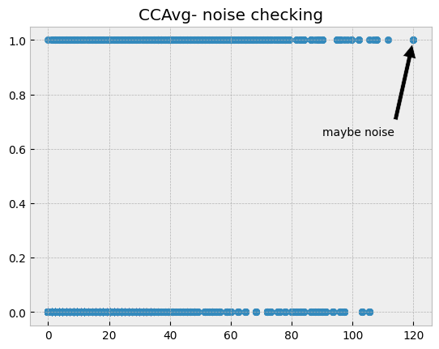

```python
plt.scatter(df['CCAvg'], df["Personal_Loan"])
plt.annotate('maybe noise', xy=(120, 1), xytext=(90, 0.65),
              arrowprops=dict(facecolor='black', shrink=0.05))
plt.title("CCAvg- noise checking")

plt.show()
```

```python
Noise_ccavg  = df[df['CCAvg'] > 119]
Noise_ccavg
```

|  | Age | Experience | Income | ZIP_Code | Family | CCAvg | Education | Mortgage | Personal_Loan | Securities_Account | CD_Account | Online | CreditCard |
| --- | --- | --- | --- | --- | --- | --- | --- | --- | --- | --- | --- | --- | --- |
| 787 | 45 | 15 | 202 | 91380 | 3 | 120.0 | 3 | 0 | 1 | 0 | 0 | 0 | 0 |
| 2101 | 35 | 5 | 203 | 95032 | 1 | 120.0 | 3 | 0 | 1 | 0 | 0 | 0 | 0 |
| 2337 | 43 | 16 | 201 | 95054 | 1 | 120.0 | 2 | 0 | 1 | 0 | 0 | 0 | 1 |

##### ✅ There are no noises in "CCAvg" column.

## **Step 3.6 | Plots**

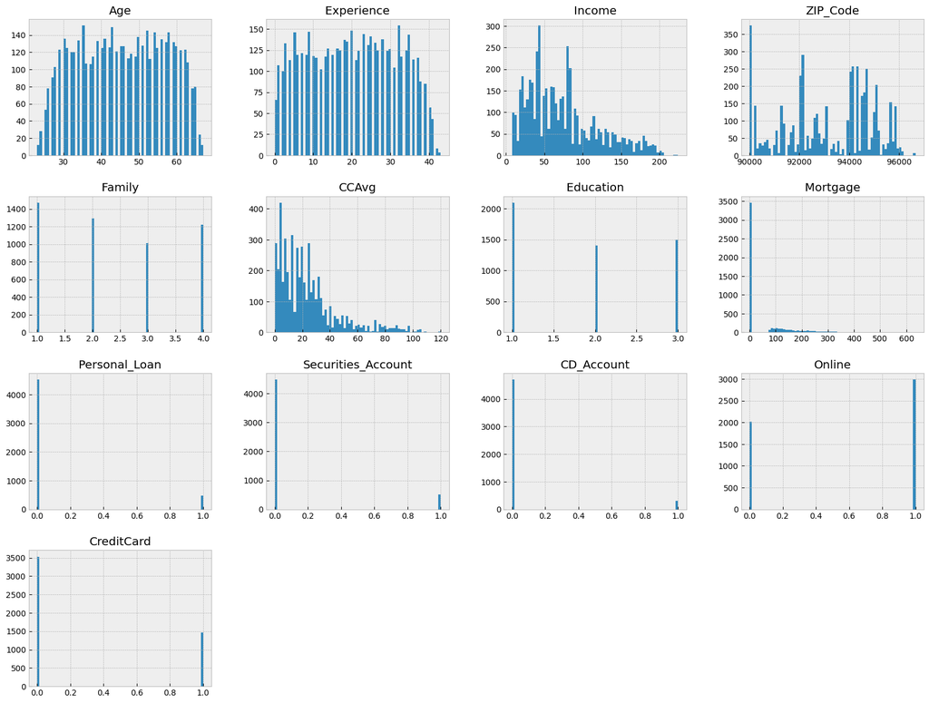

```python
df.hist(bins=70,figsize=(20,15))
plt.show()
```

##### 📍Focus on Zipcode for better visualization. 📍Extract information from ZIP code.

```python
list_zipcode = list(df['ZIP_Code'])
```

```python
country = []  # Location
lat = []  # Latitude
long = [] # Longtitude

for x in list_zipcode : # check each value of zipcode
    my_city_county = zcode.matching(str(x)) # used zipcode library
    if len(my_city_county) == 1:
        County= my_city_county[0].get('county')
        Lat = my_city_county[0].get('lat')
        Long = my_city_county[0].get('long')
    else:
        County='Notfound'
        Lat=np.NaN
        Long=np.NaN
    country.insert(0, County)
    lat.insert(0, Lat)
    long.insert(0, Long)
country.reverse()
lat.reverse()
long.reverse()

df['Location'] = country
df['Latitude'] = lat
df['Longtitude'] = long
```

```python
df
```

|  | Age | Experience | Income | ZIP_Code | Family | CCAvg | Education | Mortgage | Personal_Loan | Securities_Account | CD_Account | Online | CreditCard | Location | Latitude | Longtitude |
| --- | --- | --- | --- | --- | --- | --- | --- | --- | --- | --- | --- | --- | --- | --- | --- | --- |
| 0 | 25 | 1 | 49 | 91107 | 4 | 19.2 | 1 | 0 | 0 | 1 | 0 | 0 | 0 | Los Angeles County | 34.1620 | -118.0894 |
| 1 | 45 | 19 | 34 | 90089 | 3 | 18.0 | 1 | 0 | 0 | 1 | 0 | 0 | 0 | Los Angeles County | 34.0218 | -118.2883 |
| 2 | 39 | 15 | 11 | 94720 | 1 | 12.0 | 1 | 0 | 0 | 0 | 0 | 0 | 0 | Alameda County | 37.8746 | -122.2547 |
| 3 | 35 | 9 | 100 | 94112 | 1 | 32.4 | 2 | 0 | 0 | 0 | 0 | 0 | 0 | San Francisco County | 37.7217 | -122.4446 |
| 4 | 35 | 8 | 45 | 91330 | 4 | 12.0 | 2 | 0 | 0 | 0 | 0 | 0 | 1 | Los Angeles County | 34.2429 | -118.5273 |
| ... | ... | ... | ... | ... | ... | ... | ... | ... | ... | ... | ... | ... | ... | ... | ... | ... |
| 4995 | 29 | 3 | 40 | 92697 | 1 | 22.8 | 3 | 0 | 0 | 0 | 0 | 1 | 0 | Orange County | 33.6473 | -117.8409 |
| 4996 | 30 | 4 | 15 | 92037 | 4 | 4.8 | 1 | 85 | 0 | 0 | 0 | 1 | 0 | San Diego County | 32.8668 | -117.2482 |
| 4997 | 63 | 39 | 24 | 93023 | 2 | 3.6 | 3 | 0 | 0 | 0 | 0 | 0 | 0 | Ventura County | 34.5210 | -119.2477 |
| 4998 | 65 | 40 | 49 | 90034 | 3 | 6.0 | 2 | 0 | 0 | 0 | 0 | 1 | 0 | Los Angeles County | 34.0293 | -118.3994 |
| 4999 | 28 | 4 | 83 | 92612 | 3 | 9.6 | 1 | 0 | 0 | 0 | 0 | 1 | 1 | Orange County | 33.6615 | -117.8217 |

4999 rows × 16 columns

```python
df.info()
```

```
<class 'pandas.core.frame.DataFrame'>
Index: 4999 entries, 0 to 4999
Data columns (total 16 columns):
 #   Column              Non-Null Count  Dtype
---  ------              --------------  -----
 0   Age                 4999 non-null   int64
 1   Experience          4999 non-null   int64
 2   Income              4999 non-null   int64
 3   ZIP_Code            4999 non-null   int64
 4   Family              4999 non-null   int64
 5   CCAvg               4999 non-null   float64
 6   Education           4999 non-null   int64
 7   Mortgage            4999 non-null   int64
 8   Personal_Loan       4999 non-null   int64
 9   Securities_Account  4999 non-null   int64
 10  CD_Account          4999 non-null   int64
 11  Online              4999 non-null   int64
 12  CreditCard          4999 non-null   int64
 13  Location            4999 non-null   object
 14  Latitude            4966 non-null   object
 15  Longtitude          4966 non-null   object
dtypes: float64(1), int64(12), object(3)
memory usage: 663.9+ KB
```

```python
df = df.astype({'Latitude':float, 'Longtitude': float})
```

```python
df.head()
```

|  | Age | Experience | Income | ZIP_Code | Family | CCAvg | Education | Mortgage | Personal_Loan | Securities_Account | CD_Account | Online | CreditCard | Location | Latitude | Longtitude |
| --- | --- | --- | --- | --- | --- | --- | --- | --- | --- | --- | --- | --- | --- | --- | --- | --- |
| 0 | 25 | 1 | 49 | 91107 | 4 | 19.2 | 1 | 0 | 0 | 1 | 0 | 0 | 0 | Los Angeles County | 34.1620 | -118.0894 |
| 1 | 45 | 19 | 34 | 90089 | 3 | 18.0 | 1 | 0 | 0 | 1 | 0 | 0 | 0 | Los Angeles County | 34.0218 | -118.2883 |
| 2 | 39 | 15 | 11 | 94720 | 1 | 12.0 | 1 | 0 | 0 | 0 | 0 | 0 | 0 | Alameda County | 37.8746 | -122.2547 |
| 3 | 35 | 9 | 100 | 94112 | 1 | 32.4 | 2 | 0 | 0 | 0 | 0 | 0 | 0 | San Francisco County | 37.7217 | -122.4446 |
| 4 | 35 | 8 | 45 | 91330 | 4 | 12.0 | 2 | 0 | 0 | 0 | 0 | 0 | 1 | Los Angeles County | 34.2429 | -118.5273 |

```python
df.describe(include='all')
```

|  | Age | Experience | Income | ZIP_Code | Family | CCAvg | Education | Mortgage | Personal_Loan | Securities_Account | CD_Account | Online | CreditCard | Location | Latitude | Longtitude |
| --- | --- | --- | --- | --- | --- | --- | --- | --- | --- | --- | --- | --- | --- | --- | --- | --- |
| count | 4999.000000 | 4999.000000 | 4999.000000 | 4999.000000 | 4999.000000 | 4999.000000 | 4999.000000 | 4999.000000 | 4999.000000 | 4999.000000 | 4999.000000 | 4999.000000 | 4999.000000 | 4999 | 4966.000000 | 4966.000000 |
| unique | NaN | NaN | NaN | NaN | NaN | NaN | NaN | NaN | NaN | NaN | NaN | NaN | NaN | 39 | NaN | NaN |
| top | NaN | NaN | NaN | NaN | NaN | NaN | NaN | NaN | NaN | NaN | NaN | NaN | NaN | Los Angeles County | NaN | NaN |
| freq | NaN | NaN | NaN | NaN | NaN | NaN | NaN | NaN | NaN | NaN | NaN | NaN | NaN | 1095 | NaN | NaN |
| mean | 45.337267 | 20.133627 | 73.784757 | 93169.275455 | 2.396079 | 23.258468 | 1.880776 | 56.510102 | 0.096019 | 0.104421 | 0.060412 | 0.596719 | 0.293859 | NaN | 35.792110 | -120.037847 |
| std | 11.464033 | 11.416124 | 46.032281 | 1759.630610 | 1.147554 | 20.972776 | 0.839804 | 101.720837 | 0.294647 | 0.305836 | 0.238273 | 0.490605 | 0.455574 | NaN | 2.098821 | 2.092821 |
| min | 23.000000 | 0.000000 | 8.000000 | 90005.000000 | 1.000000 | 0.000000 | 1.000000 | 0.000000 | 0.000000 | 0.000000 | 0.000000 | 0.000000 | 0.000000 | NaN | 32.554700 | -124.099400 |
| 25% | 35.000000 | 10.000000 | 39.000000 | 91911.000000 | 1.000000 | 8.400000 | 1.000000 | 0.000000 | 0.000000 | 0.000000 | 0.000000 | 0.000000 | 0.000000 | NaN | 34.003300 | -122.148500 |
| 50% | 45.000000 | 20.000000 | 64.000000 | 93437.000000 | 2.000000 | 18.000000 | 2.000000 | 0.000000 | 0.000000 | 0.000000 | 0.000000 | 1.000000 | 0.000000 | NaN | 35.373600 | -120.042400 |
| 75% | 55.000000 | 30.000000 | 98.000000 | 94608.000000 | 3.000000 | 30.000000 | 3.000000 | 101.000000 | 0.000000 | 0.000000 | 0.000000 | 1.000000 | 1.000000 | NaN | 37.748700 | -118.089400 |
| max | 67.000000 | 43.000000 | 224.000000 | 96651.000000 | 4.000000 | 120.000000 | 3.000000 | 635.000000 | 1.000000 | 1.000000 | 1.000000 | 1.000000 | 1.000000 | NaN | 41.758900 | -115.630500 |

##### ⚠️ We have missing values in "Latitude" and "Longtitude" column.

```python
df[df['Location'] == 'Notfound']['ZIP_Code'].value_counts()
```

```
ZIP_Code
92717    22
96651     6
92634     5
Name: count, dtype: int64
```

##### 📍 Found information about the ZIP codes mentioned in the output cell above.

##### 📬 U.S. ZIP Code 92717

```python
zcode = list(df[df['ZIP_Code']==92717].index)

for x in zcode :
    df.at[x, 'Location']='Irvine'
    df.at[x, 'Latitude'] = 33.6462
    df.at[x, 'Longtitude'] = -117.8398
```

##### 📬 U.S. ZIP Code 92634

```python
zcode = list(df[df['ZIP_Code']==92634].index)

for x in zcode :
    df.at[x, 'Location']='Fullerton'
    df.at[x, 'Latitude'] = 33.8739
    df.at[x, 'Longtitude'] = -117.9028
```

##### ⚠️ U.A.E. ZIP Code 96651 📍 Drop this ZIP Code

```python
z = list(df[df['ZIP_Code']==96651].index)

for x in z :
    df.drop(index=x, inplace=True)
```

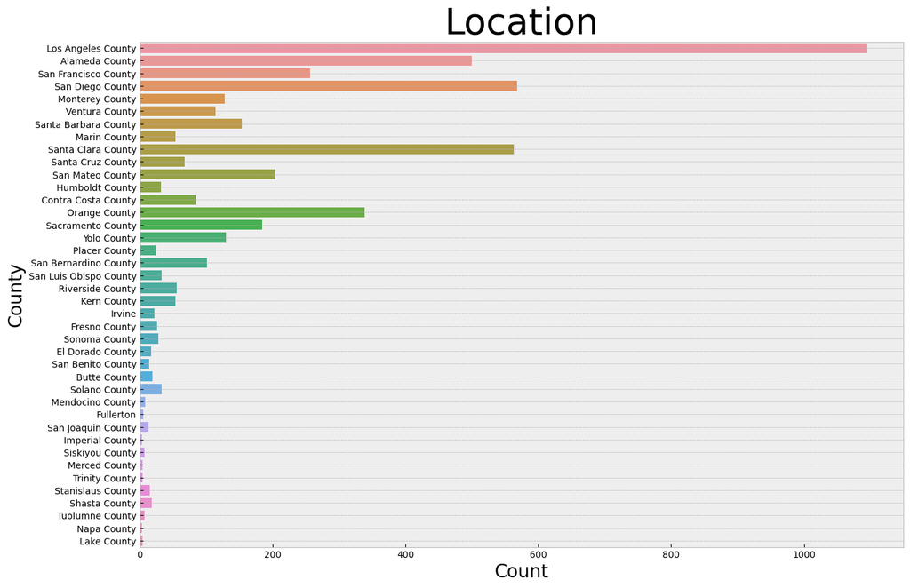

```python
plt.figure(figsize=(15, 10))
sns.countplot(y='Location', data=df)
plt.title('Location', fontsize=40)
plt.grid()
plt.xlabel('Count', fontsize=20)
plt.ylabel('County', fontsize=20)
plt.show()
```

```python
req_counts = df['Location'].value_counts().nlargest(10)
fig = px.pie(df, names=req_counts.index, values=req_counts.values,
              hole=0.2, width=1100, height=500
            )
fig.update_layout(title='Top 10 County', title_x=0.45, title_font=dict(size=24))

fig.show()
```

[interactive chart not shown]

```python
# define the world map centered around Canada with a low zoom level
map = folium.Map(location=[38, -120], zoom_start=6)


# instantiate a feature group for the incidents in the dfframe
incidents = folium.map.FeatureGroup()


for Latitude, Longtitude, flag in zip(df.Latitude, df.Longtitude, df['Personal_Loan']):
    if flag==0:
        incidents.add_child(
            folium.vector_layers.CircleMarker(
                [Latitude, Longtitude],
                radius=1, # define how big you want the circle markers to be
                color='red',
                fill=True,
                fill_color='red',
                fill_opacity=0.6
            )
        )
    else:
        incidents.add_child(
            folium.vector_layers.CircleMarker(
                [Latitude, Longtitude],
                radius=5, # define how big you want the circle markers to be
                color='green',
                fill=True,
                fill_color='green',
                fill_opacity=1
            )
        )


# add incidents to map
map.add_child(incidents)
```

Make this Notebook Trusted to load map: File -> Trust Notebook

[interactive chart not shown]

```python
numeric_columns = df.select_dtypes(include=['int64', 'float64']).columns
numeric_df = df[numeric_columns]

fig = px.imshow(numeric_df.corr(), color_continuous_scale="Reds",
                color_continuous_midpoint=0)
fig.update_layout(
    title={
        'text': "Correlation Heatmap",
        'font': {'size': 24},
        'x': 0.5,
        'xanchor': 'center',
        'yanchor': 'top'
    },
    width=1000,
    height=800,
    xaxis_showgrid=True,
    yaxis_showgrid=True,
    yaxis_autorange='reversed')

fig.show()
```

[interactive chart not shown]

# Step 4 | Modeling

## **Step 4.1 | Features selection**

##### 📍 Preparing features for modeling

```python
X = df.drop(columns=['Personal_Loan', 'Location', 'Latitude', 'Longtitude', 'ZIP_Code'])
y = df.Personal_Loan.values.reshape(-1, 1)
```

```python
X_train, X_test, y_train, y_test = train_test_split(X, y, test_size=0.2, random_state=0)
```

```python
row, col = X_train.shape
print("X_train have",row,"rows and",col,"columns.")
row, col = X_test.shape
print("X_test have",row,"rows and",col,"columns.")
```

```
X_train have 3994 rows and 11 columns.
X_test have 999 rows and 11 columns.
```

## **Step 4.2 | Logestic Regression**

```python
hyperparameters = [{
'penalty' : ['l1', 'l2'],
    'C' : [0.001, 0.01, 0.1, 1, 10, 100, 1000],
    'solver' : ['liblinear','saga', 'newton-cg', 'sag', 'lbfgs'],
    'max_iter' : [100, 1000]
}]
logreg = LogisticRegression()
grid_search = GridSearchCV(logreg, hyperparameters, scoring='f1', cv = 3, verbose=True, n_jobs=1)
grid_search.fit(X_train, y_train)
best_logreg_params = grid_search.best_params_
```

```
Fitting 3 folds for each of 140 candidates, totalling 420 fits
```

```python
print(best_logreg_params)
```

```
{'C': 100, 'max_iter': 1000, 'penalty': 'l2', 'solver': 'lbfgs'}
```

```python
best_logreg = LogisticRegression(**best_logreg_params)
best_logreg.fit(X_train, y_train)
y_pred_log = best_logreg.predict(X_test)
```

```python
f1 = metrics.f1_score(y_test, y_pred_log)
mae = metrics.mean_absolute_error(y_test, y_pred_log)
mse = metrics.mean_squared_error(y_test, y_pred_log)
r2 = metrics.r2_score(y_test, y_pred_log)

print("F1 Score:", f1)
print("Mean Absolut Error:", mae)
print("Mean Square Error:", mse)
print("R2Score:", r2)
```

```
F1 Score: 0.6710526315789473
Mean Absolut Error: 0.05005005005005005
Mean Square Error: 0.05005005005005005
R2Score: 0.39548337125429633
```

```python
print("Accuracy:", metrics.accuracy_score(y_test,y_pred_log))
y_pred_log_train = best_logreg.predict(X_train)
print("Accuracy on train:", metrics.accuracy_score(y_train,y_pred_log_train))
```

```
Accuracy: 0.94994994994995
Accuracy on train: 0.9521782674011017
```

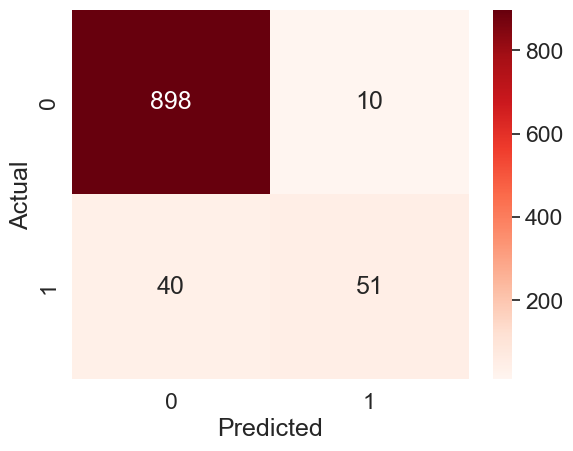

```python
logreg_cm = confusion_matrix(y_test, y_pred_log)
sns.set(font_scale=1.5)
plt.figure(dpi=100)
sns.heatmap(logreg_cm, annot=True, cmap='Reds', fmt='g')
plt.xlabel('Predicted')
plt.ylabel('Actual')
plt.show()
```

```python
precision = metrics.precision_score(y_test, y_pred_log)
recall = metrics.recall_score(y_test, y_pred_log)

print("Precision:", precision)
print("Recall:", recall)
```

```
Precision: 0.8360655737704918
Recall: 0.5604395604395604
```

```python
print(classification_report(y_test, y_pred_log))
```

```
              precision    recall  f1-score   support

           0       0.96      0.99      0.97       908
           1       0.84      0.56      0.67        91

    accuracy                           0.95       999
   macro avg       0.90      0.77      0.82       999
weighted avg       0.95      0.95      0.95       999
```

## **Step 4.3 | KNN**

```python
train_accuaracy = []
test_accuaracy = []
neighbors_set = range(1,30)
for n_neighbor in neighbors_set:
    knn_model = KNeighborsClassifier(n_neighbors=n_neighbor)
    knn_model.fit(X_train,y_train.ravel())
    train_accuaracy.append(knn_model.score(X_train,y_train))
    test_accuaracy.append(knn_model.score(X_test,y_test))
```

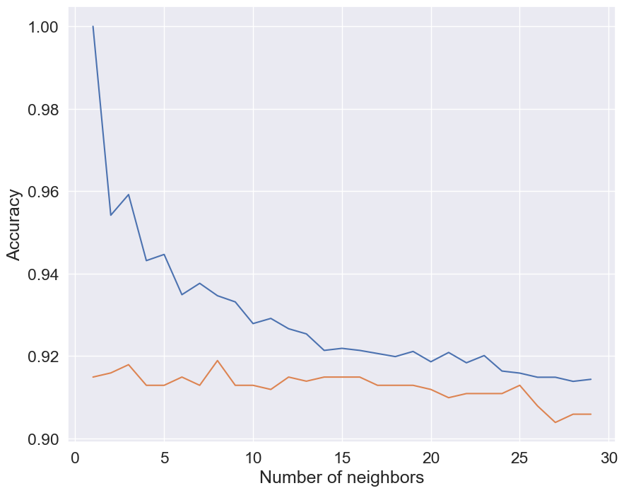

```python
plt.figure(figsize=(10,8))
plt.plot(neighbors_set,train_accuaracy)
plt.plot(neighbors_set,test_accuaracy)
plt.ylabel('Accuracy')
plt.xlabel('Number of neighbors')
plt.grid()
plt.grid()
```

```python
hyperparameters = [{
    'n_neighbors': [3, 5, 7, 9, 11],
    'weights': ['uniform', 'distance'],
    'p': [1, 2]
}]

knn = KNeighborsClassifier()
grid_search = GridSearchCV(knn, hyperparameters, scoring='f1', cv=3, verbose=True, n_jobs=1)
grid_search.fit(X_train, y_train)
best_knn_params = grid_search.best_params_;
```

```
Fitting 3 folds for each of 20 candidates, totalling 60 fits
```

```python
print(best_knn_params)
```

```
{'n_neighbors': 3, 'p': 1, 'weights': 'distance'}
```

```python
best_knn = KNeighborsClassifier(**best_knn_params)
best_knn.fit(X_train, y_train.ravel())
y_pred_knn = best_knn.predict(X_test)
```

```python
f1 = metrics.f1_score(y_test, y_pred_knn)
mae = metrics.mean_absolute_error(y_test, y_pred_knn)
mse = metrics.mean_squared_error(y_test, y_pred_knn)
r2 = metrics.r2_score(y_test, y_pred_knn)

print("F1 Score:", f1)
print("Mean Absolut Error:", mae)
print("Mean Square Error:", mse)
print("R2Score:", r2)
```

```
F1 Score: 0.5
Mean Absolut Error: 0.07607607607607608
Mean Square Error: 0.07607607607607608
R2Score: 0.08113472430653035
```

```python
print("Accuracy:", metrics.accuracy_score(y_test,y_pred_knn))
y_pred_knn_train = best_knn.predict(X_train)
print("Accuracy on train:", metrics.accuracy_score(y_train,y_pred_knn_train))
```

```
Accuracy: 0.923923923923924
Accuracy on train: 1.0
```

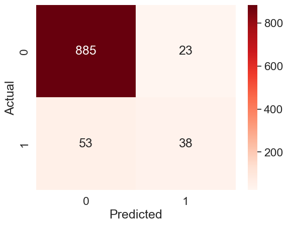

```python
knn_cm = confusion_matrix(y_test, y_pred_knn)
sns.set(font_scale=1.5)
plt.figure(dpi=100)
sns.heatmap(knn_cm, annot=True, cmap='Reds', fmt='g')
plt.xlabel('Predicted')
plt.ylabel('Actual')
plt.show()
```

## **Step 4.4 | Complement Naive Bayes (CNB)**

```python
hyperparameters = {
    'alpha': [0.1, 1, 10],
    'fit_prior': [True, False]
}
cnb = ComplementNB()
grid_search = GridSearchCV(cnb, hyperparameters, scoring='f1', cv=5)
grid_search.fit(X_train, y_train)

best_params = grid_search.best_params_
```

```python
print(best_params)
```

```
{'alpha': 0.1, 'fit_prior': True}
```

```python
best_cnb = ComplementNB(alpha=0.1, fit_prior=True)
best_cnb.fit(X_train, y_train)
y_pred_cnb = best_cnb.predict(X_test)
```

```python
f1 = metrics.f1_score(y_test, y_pred_cnb)
mae = metrics.mean_absolute_error(y_test, y_pred_cnb)
mse = metrics.mean_squared_error(y_test, y_pred_cnb)
r2 = metrics.r2_score(y_test, y_pred_cnb)

print("F1 Score:", f1)
print("Mean Absolut Error:", mae)
print("Mean Square Error:", mse)
print("R2Score:", r2)
```

```
F1 Score: 0.3403141361256545
Mean Absolut Error: 0.25225225225225223
Mean Square Error: 0.25225225225225223
R2Score: -2.046763808878347
```

```python
print("Accuracy:", metrics.accuracy_score(y_test,y_pred_cnb))
y_pred_cnb_train = best_cnb.predict(X_train)
print("Accuracy on train:", metrics.accuracy_score(y_train,y_pred_cnb_train))
```

```
Accuracy: 0.7477477477477478
Accuracy on train: 0.7463695543314972
```

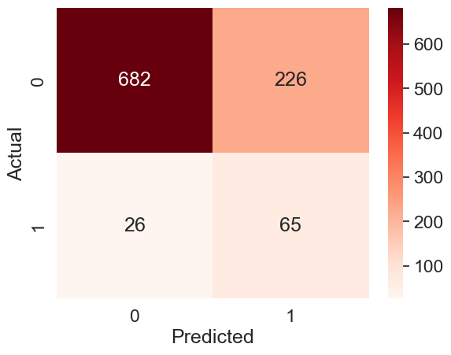

```python
cnb_cm = confusion_matrix(y_test, y_pred_cnb)
sns.set(font_scale=1.5)
plt.figure(dpi=100)
sns.heatmap(cnb_cm, annot=True, cmap='Reds', fmt='g')
plt.xlabel('Predicted')
plt.ylabel('Actual')
plt.show()
```

```python
precision = metrics.precision_score(y_test, y_pred_cnb)
recall = metrics.recall_score(y_test, y_pred_cnb)

print("Precision:", precision)
print("Recall:", recall)
```

```
Precision: 0.22336769759450173
Recall: 0.7142857142857143
```

```python
print(classification_report(y_test, y_pred_cnb))
```

```
              precision    recall  f1-score   support

           0       0.96      0.75      0.84       908
           1       0.22      0.71      0.34        91

    accuracy                           0.75       999
   macro avg       0.59      0.73      0.59       999
weighted avg       0.90      0.75      0.80       999
```

## **Step 4.5 | Decision Tree classifier**

```python
hyperparameters = [{
    'criterion': ['gini', 'entropy'],
    'max_depth': [None, 5, 10, 20],
    'min_samples_split': [2, 5, 10],
    'min_samples_leaf': [1, 2, 4]
}]

dt = DecisionTreeClassifier()
grid_search = GridSearchCV(dt, hyperparameters, scoring='f1', cv=5, verbose=True, n_jobs=1)
grid_search.fit(X_train, y_train)
best_dt_params = grid_search.best_params_
```

```
Fitting 5 folds for each of 72 candidates, totalling 360 fits
```

```python
print(best_dt_params)
```

```
{'criterion': 'gini', 'max_depth': 5, 'min_samples_leaf': 4, 'min_samples_split': 10}
```

```python
best_dt = DecisionTreeClassifier(**best_dt_params)
best_dt.fit(X_train, y_train.ravel())
y_pred_dt = best_dt.predict(X_test)
```

```python
f1 = metrics.f1_score(y_test, y_pred_dt)
mae = metrics.mean_absolute_error(y_test, y_pred_dt)
mse = metrics.mean_squared_error(y_test, y_pred_dt)
r2 = metrics.r2_score(y_test, y_pred_dt)

print("F1 Score:", f1)
print("Mean Absolut Error:", mae)
print("Mean Square Error:", mse)
print("R2Score:", r2)
```

```
F1 Score: 0.8606060606060606
Mean Absolut Error: 0.023023023023023025
Mean Square Error: 0.023023023023023025
R2Score: 0.7219223507769763
```

```python
print("Accuracy:", metrics.accuracy_score(y_test,y_pred_dt))
y_pred_dt_train = best_dt.predict(X_train)
print("Accuracy on train:", metrics.accuracy_score(y_train,y_pred_dt_train))
```

```
Accuracy: 0.9769769769769769
Accuracy on train: 0.9892338507761642
```

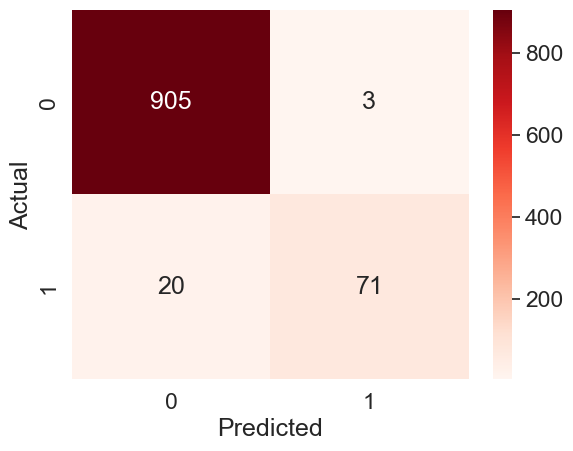

```python
dt_cm = confusion_matrix(y_test, y_pred_dt)
sns.set(font_scale=1.5)
plt.figure(dpi=100)
sns.heatmap(dt_cm, annot=True, cmap='Reds', fmt='g')
plt.xlabel('Predicted')
plt.ylabel('Actual')
plt.show()
```

## **Step 4.6 | Random Forest classifier**

```python
hyperparameters = [{
    'n_estimators': [100, 200, 300],
    'criterion': ['gini', 'entropy'],
    'max_depth': [2, 5, 10, 20],
    'max_features':[2,3,4,5]
}]

rf = RandomForestClassifier()
grid_search = GridSearchCV(rf, hyperparameters, scoring='f1', cv=5, verbose=True, n_jobs=1)
grid_search.fit(X_train, y_train)
```

```
Fitting 5 folds for each of 96 candidates, totalling 480 fits
```

```
GridSearchCV(cv=5, estimator=RandomForestClassifier(), n_jobs=1,
             param_grid=[{'criterion': ['gini', 'entropy'],
                          'max_depth': [2, 5, 10, 20],
                          'max_features': [2, 3, 4, 5],
                          'n_estimators': [100, 200, 300]}],
             scoring='f1', verbose=True)
```

```python
best_rf_params = grid_search.best_params_
print(best_rf_params)
```

```
{'criterion': 'gini', 'max_depth': 20, 'max_features': 5, 'n_estimators': 100}
```

```python
best_rf = RandomForestClassifier(**best_rf_params)
best_rf.fit(X_train, y_train.ravel())
y_pred_rf = best_rf.predict(X_test)
```

```python
f1 = metrics.f1_score(y_test, y_pred_rf)
mae = metrics.mean_absolute_error(y_test, y_pred_rf)
mse = metrics.mean_squared_error(y_test, y_pred_rf)
r2 = metrics.r2_score(y_test, y_pred_rf)

print("F1 Score:", f1)
print("Mean Absolut Error:", mae)
print("Mean Square Error:", mse)
print("R2Score:", r2)
```

```
F1 Score: 0.9302325581395348
Mean Absolut Error: 0.012012012012012012
Mean Square Error: 0.012012012012012012
R2Score: 0.854916009101031
```

```python
print("Accuracy:", metrics.accuracy_score(y_test,y_pred_rf))
y_pred_rf_train = best_rf.predict(X_train)
print("Accuracy on train:", metrics.accuracy_score(y_train,y_pred_rf_train))
```

```
Accuracy: 0.987987987987988
Accuracy on train: 1.0
```

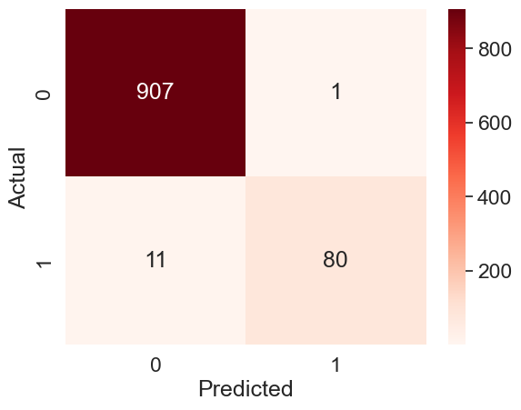

```python
rf_cm = confusion_matrix(y_test, y_pred_rf)
sns.set(font_scale=1.5)
plt.figure(dpi=100)
sns.heatmap(rf_cm, annot=True, cmap='Reds', fmt='g')
plt.xlabel('Predicted')
plt.ylabel('Actual')
plt.show()
```

## **Step 4.7 | Result**

### 📍 After conducting an analysis of different machine learning algorithms and assessing their scores and error rates, it has been concluded that the Random Forest classifier is the optimal algorithm for the "Bank_Personal_Loan" dataset.

#### Author: Mohammadaref Ahmadpoor

###### [Github](https://github.com/MohammadarefAhmadpoor)

###### [Kaggle](https://www.kaggle.com/ahmadpour79)

###### [Linkedin](https://www.linkedin.com/in/mohammadaref-ahmadpoor)